# Age, time and the international correlation of cervical cancer

Rosa Schulte-Frohlinde

11 January 2019

# 1. Update on the internation correlation of HPV and cervical cancer

### 1.2 Methods

The strength of the international correlation between high-risk HPV prevalence and cervical cancer incidence rates was assessed using the Spearman rank correlation coefficient.

```r
for (i in levels(inc.prev.upd$age.grp)){
  spear$all[[str_c(i)]] <- cor.test(x = inc.prev.upd$prev[inc.prev.upd$age.grp == i],
                                    y = inc.prev.upd$IR[inc.prev.upd$age.grp == i],
                     alternative = "two.sided",
                     method = "spearman",
                     exact = FALSE)
  }
```

Then a linear Poisson regression model was fitted to the aggregate data in each age group using high-risk HPV prevalence in each centre. *The regression model was fitted without an intercept term to satisfy the constraint that cervical cancer rates should be zero if the HPV prevalence is zero* (Figure 2).

```r
# weights for rates per 100.000 as required in poisson model
inc.prev.upd$wt <- 100000

# one regression model per 10-year age group
for(i in levels(inc.prev.upd$age.grp)) {
  nd <- data.frame("prev" = inc.prev.upd[inc.prev.upd$age.grp == i, "prev"])

  upd.glm[[i]] <- upd.glm <- glm(IR ~ prev -1, family = poisson(link = "identity"), data =
                                 inc.prev.upd[inc.prev.upd$age.grp == i,], weights = wt)

  upd.coef[[i]] <- round(coef(upd.glm[[i]])[1], 2)

  upd.p[[i]] <- ifelse(coef(summary(upd.glm[[i]]))[,4] < 0.001, "<0.0001", ">0.0001" )

  upd.pred[[i]] <- data.frame("pred" = predict(upd.glm, nd, se.fit = TRUE)$fit,
                            "age.grp" = i, "prev" = nd)
  }
```

#### Figure 1: Flow chart describing the data choice process for the update of the international correlation of high-risk HPV prevalence and cervical cancer incidence

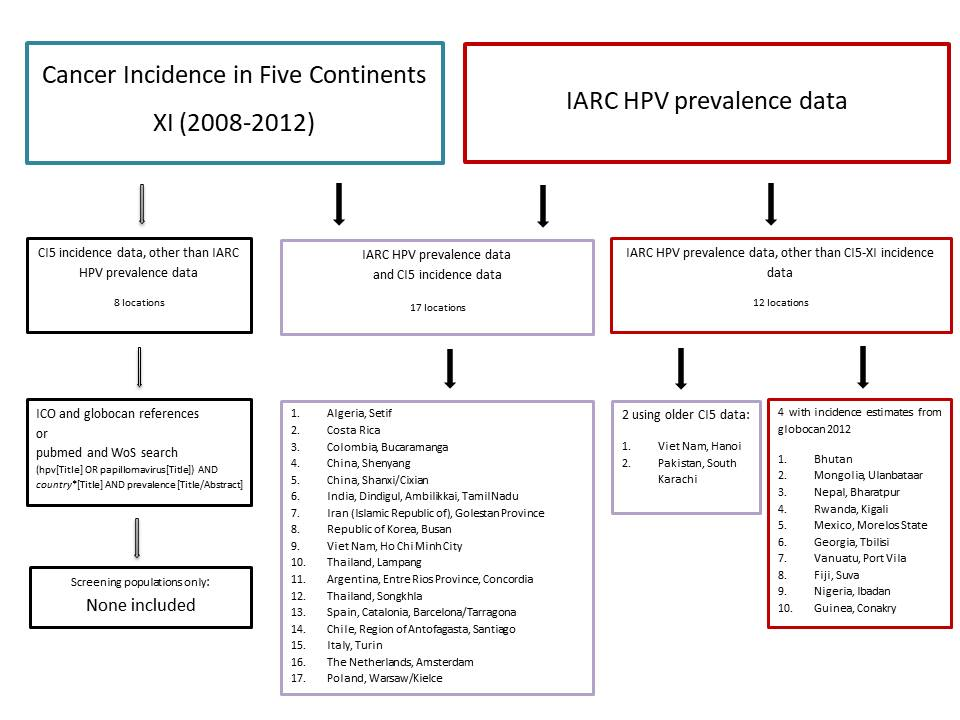

### 1.3 Results

#### Table 1: Contemporary high-risk HPV prevalence (%) (**n** being the total number of women included in the HPV study aged 25-64 years)

| Location | n | Study year | 25-34y (%) | 35-44y (%) | 45-54y (%) | 55-64y (%) |
| --- | --- | --- | --- | --- | --- | --- |
| Algeria | 717 | 2007-2008 | 3.2 | 3.3 | 4.9 | 8.6 |
| Argentina | 712 | 1998-1998 | 16.1 | 10.8 | 6.2 | 6.3 |
| Bhutan | 1609 | 2004-2008 | 18.9 | 14.3 | 11.2 | 7.3 |
| Chile | 725 | 2001-2003 | 8.1 | 7.0 | 6.5 | 8.3 |
| China(Shanxi) | 617 | 2004-2004 | 6.9 | 17.0 | 14.1 | 9.9 |
| China(Shenyang) | 645 | 2005-2005 | 12.1 | 12.4 | 13.5 | 5.4 |
| Colombia | 2857 | 1993-1995 | 10.9 | 6.9 | 1.4 | 7.4 |
| Costa Rica | 691 | 1993-1994 | 11.8 | 9.7 | 7.7 | 6.2 |
| Fiji | 1109 | 2003-2007 | 17.7 | 10.4 | 9.9 | 5.7 |
| Georgia | 961 | 2007-2007 | 12.2 | 4.8 | 6.2 | 3.6 |
| Guinea | 589 | 2006-2006 | 28.7 | 24.4 | 35.8 | 32.8 |
| India | 1557 | 2004-2004 | 11.2 | 14.1 | 12.3 | 11.1 |
| Iran | 751 | 2013-2014 | 4.8 | 4.0 | 6.2 | 3.4 |
| Italy | 911 | 2002-2002 | 11.1 | 7.9 | 3.9 | 3.5 |
| Mexico | 903 | 1996-1999 | 6.1 | 3.0 | 7.3 | 9.1 |
| Mongolia | 773 | 2005-2005 | 24.9 | 17.6 | 17.5 | 30.8 |
| Nepal | 746 | 2006-2007 | 5.4 | 8.0 | 5.6 | 3.1 |
| Netherlands | 3260 | 1995-1998 | 8.3 | 2.0 | 2.3 | 1.4 |
| Nigeria | 691 | 1999-1999 | 14.3 | 18.7 | 16.8 | 20.3 |
| Pakistan | 700 | 2004-2008 | 2.1 | 0.8 | 1.8 | 4.0 |
| Poland | 662 | 2006-2006 | 18.3 | 11.4 | 6.3 | 3.2 |
| Republic of Korea | 823 | 1999-2000 | 10.1 | 4.0 | 5.1 | 6.2 |
| Rwanda | 1323 | 2013-2014 | 21.2 | 14.3 | 13.0 | 9.6 |
| Spain | 634 | 1998-2000 | 1.9 | 1.7 | 0.6 | 0.0 |
| Thailand (Lampang) | 721 | 1997-1998 | 7.7 | 7.9 | 5.3 | 5.2 |
| Thailand (Songkla) | 508 | 1990-2000 | 4.5 | 0.0 | 2.3 | 0.7 |
| Vanuatu | 734 | 2009-2011 | 20.9 | 18.1 | 9.3 | 30.8 |
| Viet Nam | 676 | 1997-1997 | 5.8 | 7.0 | 4.5 | 6.1 |
| Viet Nam, Hanoi | 740 | 1997-1997 | 2.7 | 0.5 | 1.8 | 0.5 |

#### Table 2: Most recent age-specific cervical cancer incidence rates (per 100.000 women) in countries included in the IARC HPV prevalence studies

| Location | Incidence source | 25-34y (/100.000) | 35-44y (/100.000) | 45-54y (/100.000) | 55-64y (/100.000) |
| --- | --- | --- | --- | --- | --- |
| Algeria | CI5 | 1.0 | 7.0 | 18.0 | 22.4 |
| Argentina | CI5 | 16.5 | 29.6 | 39.9 | 32.5 |
| Bhutan | globocan 2018 | 6.4 | 21.2 | 47.6 | 46.1 |
| Chile | CI5 | 8.5 | 26.4 | 34.7 | 24.7 |
| China(Shanxi) | CI5 | 1.1 | 12.2 | 26.8 | 50.8 |
| China(Shenyang) | CI5 | 5.8 | 25.8 | 36.7 | 21.6 |
| Colombia | CI5 | 10.7 | 28.5 | 28.5 | 26.3 |
| Costa Rica | CI5 | 17.0 | 28.3 | 27.6 | 23.9 |
| Fiji | globocan 2018 | 19.6 | 47.0 | 73.7 | 67.2 |
| Georgia | globocan 2018 | 6.5 | 17.8 | 27.5 | 26.5 |
| Guinea | globocan 2018 | 16.2 | 53.8 | 105.2 | 155.9 |
| India | CI5 | 3.5 | 26.8 | 65.8 | 72.3 |
| Iran | CI5 | 1.7 | 7.8 | 16.5 | 17.8 |
| Italy | CI5 | 5.0 | 9.1 | 12.3 | 12.0 |
| Mexico | globocan 2018 | 9.3 | 18.0 | 23.6 | 28.3 |
| Mongolia | globocan 2018 | 12.2 | 35.7 | 61.1 | 73.9 |
| Nepal | globocan 2018 | 11.4 | 40.4 | 67.6 | 67.8 |
| Netherlands | CI5 | 10.5 | 15.8 | 13.2 | 9.5 |
| Nigeria | globocan 2018 | 4.7 | 27.9 | 62.7 | 115.6 |
| Pakistan | CI5 | 2.6 | 8.8 | 26.1 | 27.0 |
| Poland | CI5 | 3.1 | 15.4 | 28.3 | 34.3 |
| Republic of Korea | CI5 | 11.3 | 22.6 | 27.3 | 25.4 |
| Rwanda | globocan 2018 | 13.0 | 40.3 | 76.5 | 108.5 |
| Spain | CI5 | 6.1 | 13.1 | 19.2 | 16.7 |
| Thailand (Lampang) | CI5 | 7.0 | 23.8 | 33.5 | 30.0 |
| Thailand (Songkla) | CI5 | 5.4 | 17.6 | 31.8 | 32.0 |
| Vanuatu | globocan 2018 | 28.9 | 32.9 | 41.4 | 41.4 |
| Viet Nam | CI5 | 2.5 | 15.2 | 31.0 | 54.7 |
| Viet Nam, Hanoi | CI5 | 1.9 | 12.9 | 18.9 | 17.5 |

#### Figure 2: International correlation between cervical cancer incidence and high-risk HPV prevalence by 10-year age group.

The estimated spearman rank coefficients (rho) and poisson coefficients (coef) are specified for the respective age group. The black line represents the fitted Poisson model.

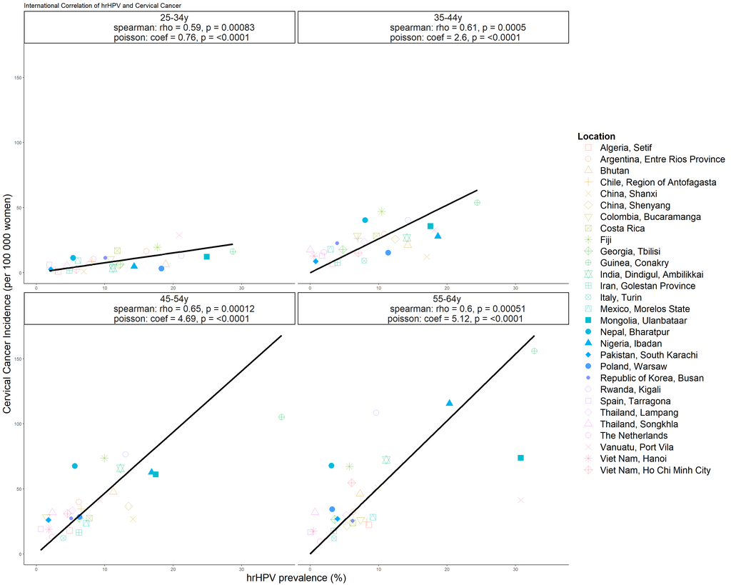

# 2. Ecological estimate of the transition rate from high-risk HPV to cervical cancer

### 2.1 Methods

To estimate the transition rate from hrHPV infection to cervical cancer we followed the multistage model describing the natural history of cervical cancer, including death as competitive risk. This allowed us to evaluate the cervical cancer incidence rate in women tested HPV+ at a certain age in the year of the prevalence study in the respective country (Figure 3).

#### Figure 3: Competitive risk model describing the natural history of cervical cancer used to estimate the transition rate from high-risk HPV infection to cervical cancer

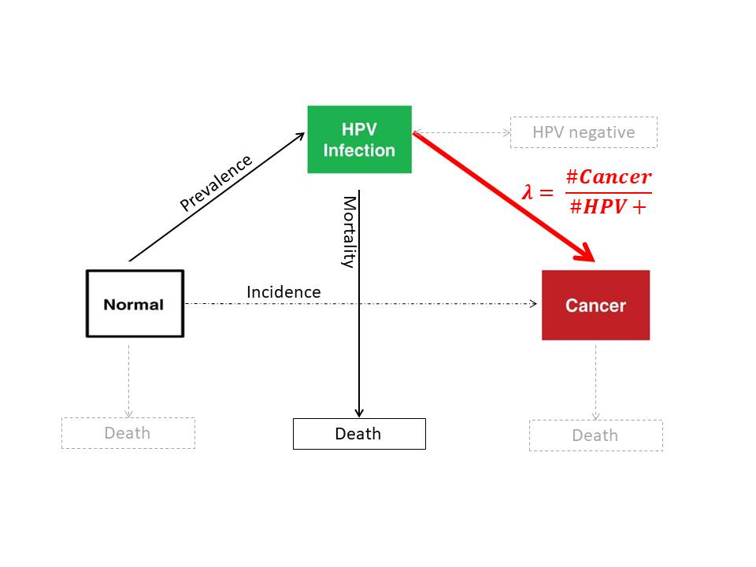

Multiplying the population and the prevalence in each age group and location yields the corresponding number of hrHPV+ women. We then used the UN population data and the CI5 incidence and UN mortality rates to estimate the number of new cancer cases and deaths per year in each age group and location.  
Assuming that the HPV prevalence is constant in each 10-year age group, thus that new infections and clearances even out, we considered the transition rate being the number of new cancer cases in the remaining event free HPV+ population for each age group, year and location.  
We shifted the age groups by one year every calendar year to then apply the respective time and age-specific rates.

```r
# YsncS = Years since HPV prevalence study
# cid = country/location identification number
# cov = low or high screening coverage
# Nicc = number of cancer cases
# Npos =  number of hrHPV positive women
# PopFemale = female population per year and country (UN data)
# mina - maxa: age range. seperate calculation for each age stratum

DpC <- Dp %>%
  ungroup() %>%
  group_by(Year, YsncS, cid, Location, cov) %>%
  summarise(Npos = sum(Npos),
          Nicc = sum(Nicc),
          prev = sum(Npos)*100/sum(PopFemale),
          IR = sum(Nicc)*100000/sum(PopFemale),  # incidence rate in whole population
          logIR = log(sum(Nicc)/sum(PopFemale)),
          se = sqrt(sum(Nicc))/sum(Npos),        # standard error of rates =
                                                 # Rate^2/cases=sqrt(cases)/personyears
          tr = sum(Nicc)/sum(Npos),              # transition rate
          log_tr = log(sum(Nicc)/sum(Npos)),     # log transition rate
          selog = sqrt(1/sum(Npos))) %>%         # var(log(k/m)) = 1/(Rate*pyears);
                                                 # se(log(k/m)) = sqrt(1/k)
  filter(YsncS <= 14) %>%
  mutate(ag = stringr::str_c(mina, "_", maxa))
```

The primary analysis only included countries with low or unclear screening coverage as screening interferes with the natural history.  
To then explore the effect of screening we repeated the analysis for the Netherlands and Italy. In both countries screening coverage is higher than 50% in a population-based screening program.

We fitted a latent class mixed model for each screening and age group to describe the time trend of the transition rates since HPV detection, thus since the year of the equivalent HPV prevalence study.  
Single-class quadratic I-splines with a random effect on intercept and slope were selected the best fitting model through the Bayesian Information Criterion using the lcmm package in R.  
The follow-up was restricted to 14 years to assure a minimum of three locations when estimating the natural transition rate without screening.  
The number of knots in the link function was fixed to a maximum of 4 to guarantee sufficient data points between the knots.

Figure 4 and 5 show the estimated transition rates and predicted overall time trend of the transition rate from hr-HPV detection to cervical cancer using the lcmm package in R. The respective code is shown here.

```r
# model fit for countries with low or unclear screening coverage
tr_lcmm_1 <- lcmm(log_tr ~ YsncS, random = ~ YsncS, subject = "Location",  ng = 1,
             data = DpC[DpC$cov == 1, ], link = "4-equi-splines")

# prediction for countries with low or unclear screening coverage
nd <- data.frame(YsncS = 0:14)
tr_pred_1 <- predictY(tr_lcmm_1, nd, methInteg = 1, draws = TRUE)
```

No significant difference between the screening groups was found within the 5- and 10-year age strata *(results not shown)*.

```r
# testing for the effect of screening on the time trend of the transition rate
tr_lcmm <- lcmm(log_tr ~ YsncS * cov, random = ~ YsncS, subject = "Location",  ng = 1,
                      data = DpC, link = "4-equi-splines")
```

We then calculated the derivatives of the mixed models in the two screening groups (Figure 6).  
This allows the display of the change in the transition rate over time, thus only of the change in the slope. This seems reasonable as there appears to be a large random effect on the intercept between the locations and thus the intercept depends strongly on the sample of locations.

```r
# low screening
tr_lambda_1 <- data.frame("YsncS" = tr_pred_1$times[2:15,]-0.5,
                              "lambda" = diff(tr_pred_1$pred[, 1]))
```

To quantify the effect of age and of screening we pooled the data over all age and screening groups and fitted a latent class linear mixed model including years since HPV study, age group and screening as covariates.

```r
# testing for the effect of age and screening on the time trend of the transition rate
tr_all<- lcmm(log_tr ~ YsncS * ag * cov, random = ~ YsncS, subject = "Location",  ng = 1,
             data = DpC_df_5, link = "4-equi-splines")
```

### 2.2 Results

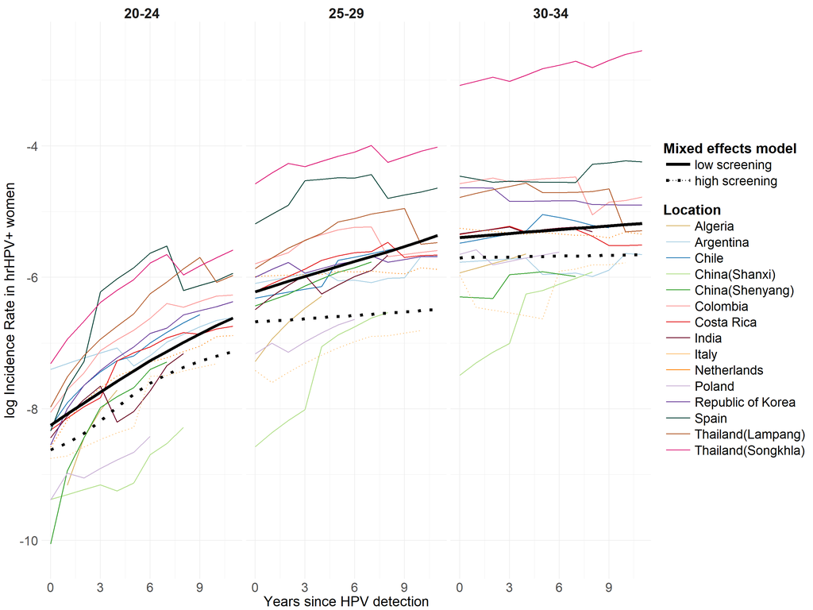

#### Figure 5: Transition rate to cervical cancer over time since high-risk HPV detection by age and screening coverage estimated using ecological data. Stratification in 5-year age groups.

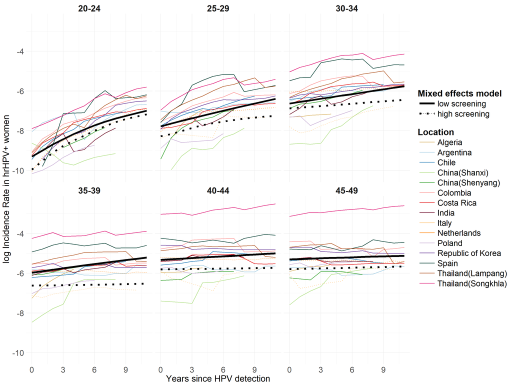

#### Figure 6: The change in cervical cancer transition rate over time since high-risk HPV detection by screening coverage

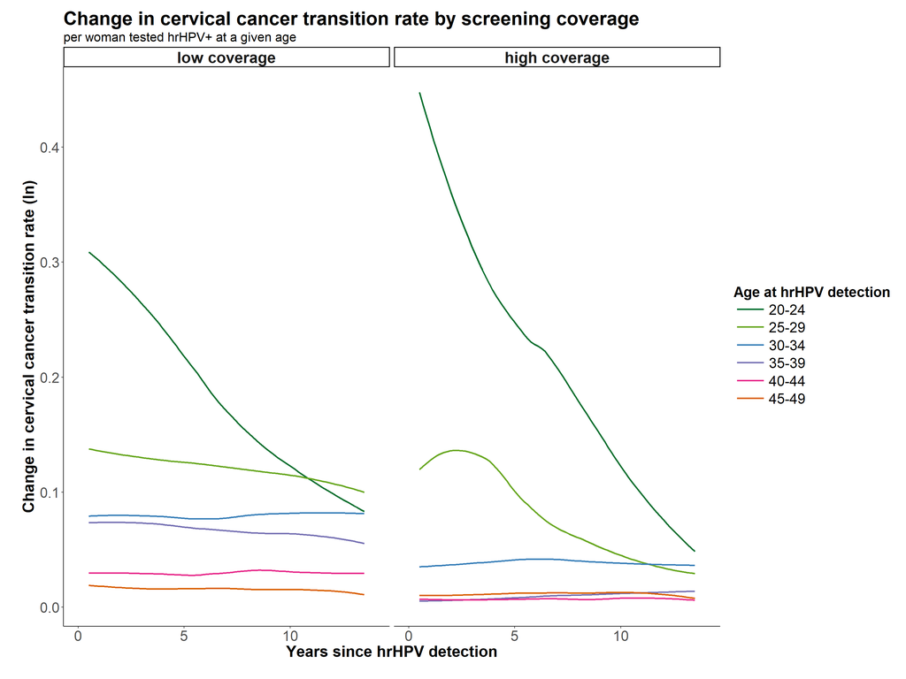

```r
# testing for the effect of age and screening on the time trend of the transition rate
tr_all_10<- lcmm(log_tr ~ YsncS * ag * cov, random = ~ YsncS, subject = "Location",  ng = 1,
             data = DpC_df_10, link = "4-equi-splines")
tr_ag_10<- lcmm(log_tr ~ YsncS * ag, random = ~ YsncS, subject = "Location",  ng = 1,
             data = DpC_df_10, link = "4-equi-splines")
```

```r
list(c(tr_all_5$BIC, tr_ag_5$BIC), c(tr_all_10$BIC, tr_ag_10$BIC))
```

```
## [[1]]
## [1] 1406.704 1405.508
##
## [[2]]
## [1] 512.9495 512.9161
```

```r
summary(tr_all_10)
```

```
## General latent class mixed model
##      fitted by maximum likelihood method
##
## lcmm(fixed = log_tr ~ YsncS * ag * cov, random = ~YsncS, subject = "Location",
##     ng = 1, link = "4-equi-splines", data = DpC_df_10)
##
## Statistical Model:
##      Dataset: DpC_df_10
##      Number of subjects: 15
##      Number of observations: 518
##      Number of observations deleted: 1
##      Number of latent classes: 1
##      Number of parameters: 16
##      Link function: Quadratic I-splines with nodes
## -10.055 -7.534 -5.013 -2.492
##
## Iteration process:
##      Convergence criteria satisfied
##      Number of iterations:  28
##      Convergence criteria: parameters= 0.00000012
##                          : likelihood= 0.0000000067
##                          : second derivatives= 0.00000000000005
##
## Goodness-of-fit statistics:
##      maximum log-likelihood: -234.81
##      AIC: 501.62
##      BIC: 512.95
##
##
## Maximum Likelihood Estimates:
##
## Fixed effects in the longitudinal model:
##
##                               coef      Se   Wald p-value
## intercept (not estimated)        0
## YsncS                      0.87205 0.15657  5.570 0.00000
## ag                         4.93780 0.36480 13.536 0.00000
## cov                        0.12734 1.92266  0.066 0.94719
## YsncS:ag                  -0.29316 0.04709 -6.225 0.00000
## YsncS:cov                 -0.25199 0.12756 -1.975 0.04822
## ag:cov                    -0.76615 0.27939 -2.742 0.00610
## YsncS:ag:cov               0.09702 0.03823  2.538 0.01115
##
##
## Variance-covariance matrix of the random-effects:
##           intercept   YsncS
## intercept   5.81035
## YsncS      -0.23034 0.01558
##
## Residual standard error (not estimated) = 1
##
## Parameters of the link function:
##
##                coef      Se   Wald p-value
## I-splines1 -2.11435 2.36488 -0.894 0.37129
## I-splines2 -2.22896 0.22379 -9.960 0.00000
## I-splines3  1.08395 0.28381  3.819 0.00013
## I-splines4  3.10999 0.09353 33.251 0.00000
## I-splines5  1.92796 0.14793 13.033 0.00000
## I-splines6  1.08603 0.19091  5.689 0.00000
```

# 3. Conclusion

In conclusion we could confirm the strong international correlation of hr-HPV prevalence and cervical cancer incidence.  
Secondly we could observe a significant effect of time since hr-HPV detection, age at hr-HPV detection and high screening coverage on the transition rate from hr-HPV to cervical cancer estimated in this ecological study. The transition rate stabilizes in higher age groups and earlier in countries with high screening coverage.